# Data Analysis Capstone Project

Patrick Martello

2024-10-23

## **Scenario**

You are a junior data analyst working on the marketing analyst team at Bellabeat, a high-tech manufacturer of health-focused products for women. Bellabeat is a successful small company, but they have the potential to become a larger player in the global smart device market. Urška Sršen, cofounder and Chief Creative Officer of Bellabeat, believes that analyzing smart device fitness data could help unlock new growth opportunities for the company. You have been asked to focus on one of Bellabeat’s products and analyze smart device data to gain insight into how consumers are using their smart devices. The insights you discover will then help guide marketing strategy for the company. You will present your analysis to the Bellabeat executive team along with your high-level recommendations for Bellabeat’s marketing strategy.

[figure not shown]

## **About the company**

Urška Sršen and Sando Mur founded Bellabeat, a high-tech company that manufactures health-focused smart products. Sršen used her background as an artist to develop beautifully designed technology that informs and inspires women around the world. Collecting data on activity, sleep, stress, and reproductive health has allowed Bellabeat to empower women with knowledge about their own health and habits. Since it was founded in 2013, Bellabeat has grown rapidly and quickly positioned itself as a tech-driven wellness company for women.

By 2016, Bellabeat had opened offices around the world and launched multiple products. Bellabeat products became available through a growing number of online retailers in addition to their own e-commerce channel on their website. The company has invested in traditional advertising media, such as radio, out-of-home billboards, print, and television, but focuses on digital marketing extensively. Bellabeat invests year-round in Google Search, maintaining active Facebook and Instagram pages, and consistently engages consumers on Twitter. Additionally, Bellabeat runs video ads on Youtube and display ads on the Google Display Network to support campaigns around key marketing dates.

Sršen knows that an analysis of Bellabeat’s available consumer data would reveal more opportunities for growth. She has asked the marketing analytics team to focus on a Bellabeat product and analyze smart device usage data in order to gain insight into how people are already using their smart devices. Then, using this information, she would like high-level recommendations for how these trends can inform Bellabeat marketing strategy.

## **Ask**

Sršen asks you to analyze smart device usage data in order to gain insight into how consumers use non-Bellabeat smart devices. She then wants you to select one Bellabeat product to apply these insights to in your presentation.

**These questions will guide your analysis:**

-What are some trends in smart device usage?  
-How could these trends apply to Bellabeat customers?  
-How could these trends help influence Bellabeat marketing strategy?

**Dataset Used:** (https://www.kaggle.com/datasets/arashnic/fitbit)

```r
knitr::opts_chunk$set(error = FALSE, warning = FALSE, message = FALSE)
```

## Setting up my environment

```r
library(tidyverse)
library(skimr)
library(here)
library(ggplot2)
```

### Importing datasets that I will be analyzing

```r
dailyactivitymarch <- read_csv('dailyActivity_mergedmarch.csv')
dailyactivityapril <- read_csv('dailyActivity_mergedapril.csv')
sleep <- read_csv('sleepDay_merged.csv')
steps <- read_csv('hourlySteps_merged.csv')
```

### Viewing the structure of the datasets

```r
str(dailyactivitymarch)
str(dailyactivityapril)
str(steps)
str(sleep)
```

# Cleaning up the data

### Removing duplicates, NAs, and unnecessary columns

```r
dailyactivitymarch <- dailyactivitymarch%>%
  drop_na() %>%
  distinct() %>%
  select(-LoggedActivitiesDistance, -TrackerDistance)

dailyactivitymarch <- dailyactivitymarch %>%
  filter(TotalDistance > 0.5)

dailyactivityapril <- dailyactivityapril%>%
  drop_na() %>%
  distinct() %>%
  select(-LoggedActivitiesDistance, -TrackerDistance) %>%
  filter(TotalDistance > .5)

sleep <- sleep %>%
  distinct()

steps <- steps %>%
  drop_na() %>%
  distinct()
```

#### Combing daily activity tables into one

```r
dailyactivity <- bind_rows(dailyactivitymarch, dailyactivityapril)
```

#### Changing timestamp from chr to date, need to put into POSIXct first to be able to pull both time and date separately

```r
dailyactivity$ActivityDate = as.POSIXct(dailyactivity$ActivityDate, format = '%m/%d/%Y')
dailyactivity$Date <- format(dailyactivity$ActivityDate, format = '%m/%d/%Y')
```

#### Changing time format so that we can split date from hour

```r
steps <- steps %>%
  mutate(
    Date = format(mdy_hms(ActivityHour, tz = Sys.timezone())),
    Time = format(mdy_hms(ActivityHour, tz = Sys.timezone())), '%H:%M:%S')
```

#### Formatting date from yyyy-dd-mm, to mm/dd/yyyy and removing original ActivityHour column

```r
steps <- steps %>%
  mutate(Date = as.Date(Date))
steps <- steps %>%
  mutate(Date = format(Date, '%m/%d/%Y'))
steps <- steps %>%
  select(-ActivityHour)
```

#### Making a column TotalActiveMinutes from the dailyactivity DF

```r
dailyactivity <- dailyactivity %>%
  mutate(TotalActiveMinutes = VeryActiveMinutes + FairlyActiveMinutes + LightlyActiveMinutes)
```

#### Making a column for hours asleep

```r
sleep <- sleep %>%
  mutate(TotalHoursAsleep = round(TotalMinutesAsleep / 60, 1))
```

#### Renaming column to HourlyStep Total from Step Total

```r
steps <- steps %>%
  mutate(HourlyStepTotal = StepTotal)
steps <- steps %>%
  select(-StepTotal)
```

#### Making sedentary hours column

```r
dailyactivity <- dailyactivity %>%
  mutate(SedentaryHours = SedentaryMinutes / 60)
dailyactivity$SedentaryHours <- round(dailyactivity$SedentaryHours, digits = 1)
```

#### Making total active hours column

```r
dailyactivity <- dailyactivity %>%
  mutate(TotalActiveHours = TotalActiveMinutes / 60)
dailyactivity$TotalActiveHours <- round(dailyactivity$TotalActiveHours, digits = 1)
```

## Analyzing the data

### Getting summary of all important variables

```r
dailyactivity %>%
  select(TotalSteps,
          TotalDistance,
          TotalActiveMinutes,
          TotalActiveHours,
          SedentaryMinutes,
          SedentaryHours,
          Calories) %>%
  summary()
```

```
##    TotalSteps    TotalDistance    TotalActiveMinutes TotalActiveHours
##  Min.   :  759   Min.   : 0.520   Min.   :  0.0      Min.   : 0.000
##  1st Qu.: 4928   1st Qu.: 3.370   1st Qu.:181.5      1st Qu.: 3.000
##  Median : 7937   Median : 5.560   Median :258.0      Median : 4.300
##  Mean   : 8391   Mean   : 6.015   Mean   :250.9      Mean   : 4.183
##  3rd Qu.:11107   3rd Qu.: 7.870   3rd Qu.:323.5      3rd Qu.: 5.400
##  Max.   :36019   Max.   :28.030   Max.   :720.0      Max.   :12.000
##  SedentaryMinutes SedentaryHours     Calories
##  Min.   :  61.0   Min.   : 1.00   Min.   : 182
##  1st Qu.: 720.0   1st Qu.:12.00   1st Qu.:1876
##  Median : 993.0   Median :16.60   Median :2229
##  Mean   : 947.2   Mean   :15.79   Mean   :2372
##  3rd Qu.:1182.0   3rd Qu.:19.70   3rd Qu.:2844
##  Max.   :1440.0   Max.   :24.00   Max.   :4900
```

According to a study by BMC Public Health (https://pmc.ncbi.nlm.nih.gov/articles/PMC5397769/), the average woman takes 4,912 steps per day, which is roughly just over 2 miles. The numbers in this dataset represent an above average group, as the 1st quartile is already above the average steps per day of women, as well as the total distance. This data is biased in that it only measure the steps of women in the United States.

This dataset isn’t the most reliable as it only measure 35 participants, and the sample size is not enough to develop any real conclusions. We also don’t know the age of the participants which would make a big difference in understanding their fitness patterns.

```r
sleep %>%
  select(TotalSleepRecords,
         TotalMinutesAsleep,
          TotalTimeInBed,
         TotalHoursAsleep) %>%
  summary()
```

```
##  TotalSleepRecords TotalMinutesAsleep TotalTimeInBed  TotalHoursAsleep
##  Min.   :1.00      Min.   : 58.0      Min.   : 61.0   Min.   : 1.000
##  1st Qu.:1.00      1st Qu.:361.0      1st Qu.:403.8   1st Qu.: 6.000
##  Median :1.00      Median :432.5      Median :463.0   Median : 7.200
##  Mean   :1.12      Mean   :419.2      Mean   :458.5   Mean   : 6.987
##  3rd Qu.:1.00      3rd Qu.:490.0      3rd Qu.:526.0   3rd Qu.: 8.200
##  Max.   :3.00      Max.   :796.0      Max.   :961.0   Max.   :13.300
```

The National Heart, Lung, and Blood Institute recommends between 7-9 hours of sleep per night for US Adults. This data shows that our participants are mostly getting enough sleep, however a little bit more would be beneficial as the mean is just outside of the 7 hour minimum recommendation.

```r
steps %>%
  select(HourlyStepTotal) %>%
  summary()
```

```
##  HourlyStepTotal
##  Min.   :    0.0
##  1st Qu.:    0.0
##  Median :   40.0
##  Mean   :  320.2
##  3rd Qu.:  357.0
##  Max.   :10554.0
```

As you can see, the average steps per hour is 320.2.

#### Finding how many different people are in each dataset

```r
n_distinct(dailyactivity$Id)
```

```
## [1] 35
```

```r
n_distinct(sleep$Id)
```

```
## [1] 24
```

```r
n_distinct(steps$Id)
```

```
## [1] 33
```

#### Creating day of the week column to make a chart comparing total steps by day of week

```r
dailyactivity$DayOfWeek <- wday(dailyactivity$ActivityDate, label = TRUE, abbr = FALSE)
dailyactivity <- dailyactivity %>% select(Id, Date, ActivityDate, DayOfWeek, everything())

#removing ActivityDate
dailyactivity <- dailyactivity %>% select(-ActivityDate)
```

#### Creating AvgStepsDay column to put in plot

```r
dailyactivity <- dailyactivity %>%
  group_by(DayOfWeek) %>%
  mutate(AvgStepsDay = mean(TotalSteps, na.rm = TRUE)) %>%
  ungroup()
dailyactivity$AvgStepsDay <- round(dailyactivity$AvgStepsDay, digits = 0)
```

### Plot of AvgStepsDay by Day of Week

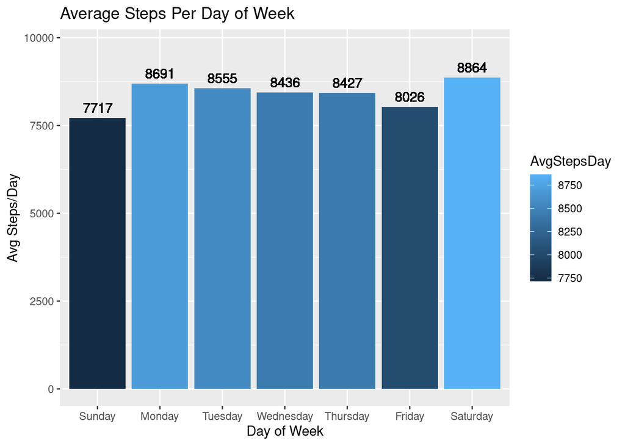

```r
ggplot(dailyactivity, aes(x = DayOfWeek, y = AvgStepsDay, fill = AvgStepsDay))+
  geom_bar(stat = 'identity')+
  geom_text(aes(label = AvgStepsDay), vjust = -0.5)+
  scale_y_continuous(limits = c(0,max(dailyactivity$AvgStepsDay) *1.1))+
  labs(title = "Average Steps Per Day of Week", x = "Day of Week", y = "Avg Steps/Day")
```

**What days of the week have the highest and lowest activity?**

### Plot for calories burned compared to sedentary minutes

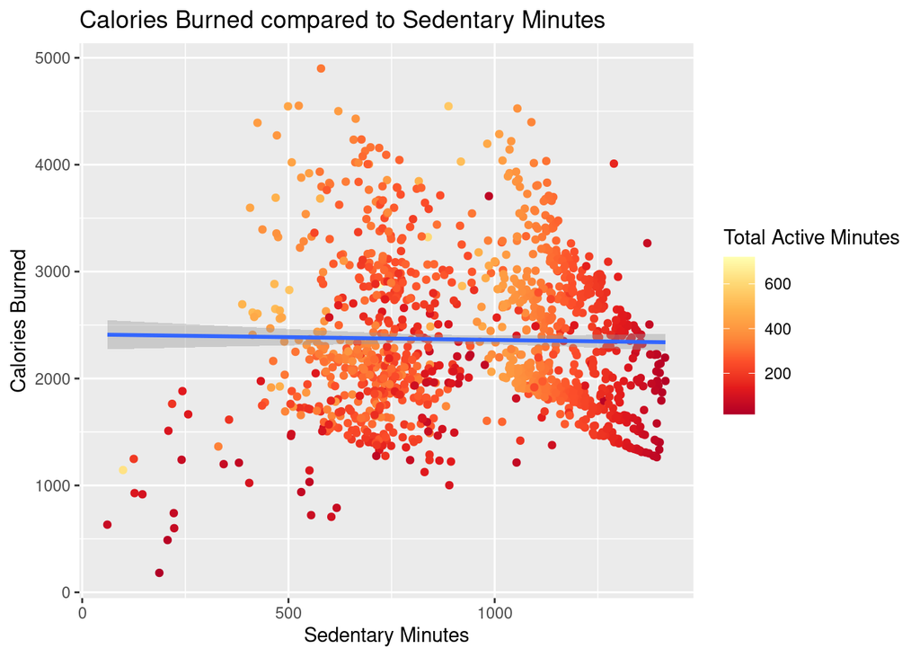

```r
ggplot(data = dailyactivity) +
  geom_point(mapping = aes(x = SedentaryMinutes, y = Calories, color = TotalActiveMinutes))+
  scale_color_distiller(palette = "YlOrRd")+
  labs(title = "Calories Burned compared to Sedentary Minutes", x = "Sedentary Minutes", y = "Calories Burned", color = "Total Active Minutes") +
  geom_smooth(method = "lm", aes(x = SedentaryMinutes, y = Calories))
```

**How does being sedentary affect calories burned?**  
Surprisingly, as seen in the chart below, there doesn’t seem to be a real correlation between minutes spent being sedentary and calories burned.

### Plot for Total Active Minutes to Calories Burned

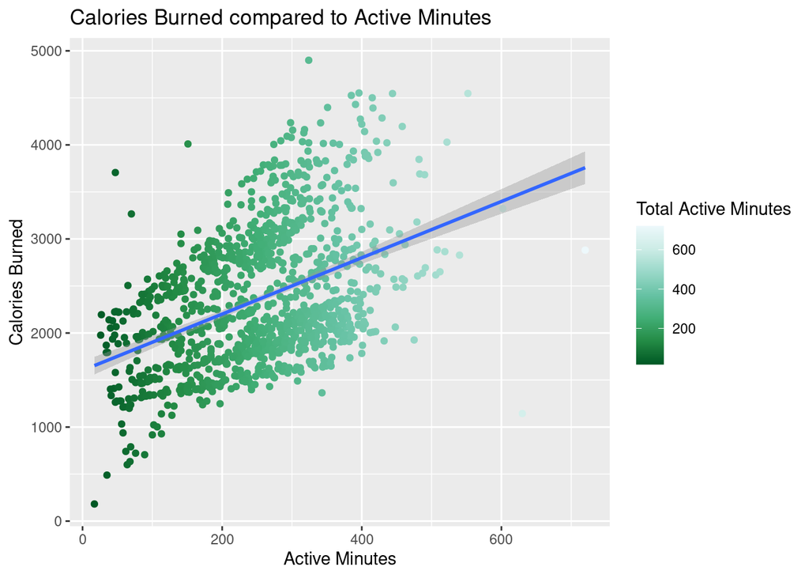

```r
ggplot(data = dailyactivity)+
  geom_point(mapping = aes(x = TotalActiveMinutes, y = Calories, color = TotalActiveMinutes))+
  scale_color_distiller(palette = "BuGn")+
  labs(title = "Calories Burned compared to Active Minutes", x = "Active Minutes", y = "Calories Burned", color = "Total Active Minutes") +
  geom_smooth(method = "lm", aes(x = TotalActiveMinutes, y = Calories))
```

**How does being active affect calories burned?**  
There is clearly a correlation between Active Minutes and Calories Burned. Need to promote more activity if people want to lose weight and be healthier.

#### Adjusting SleepDay to correct time format so I can merge with dailyactivity

```r
sleep <- sleep %>%
  mutate(SleepDay = as.POSIXct(SleepDay, format = "%m/%d/%Y %I:%M:%S %p"))
sleep <- sleep %>%
  mutate(SleepDay = format(SleepDay, '%m/%d/%Y'))

#merge dailyactivity and sleep tables
sleep <- sleep %>%
  rename(Date = SleepDay)
dailysleep <- merge(dailyactivity, sleep, by = c('Id', 'Date'))
```

## Sleep Insights

#### Plotting Calories Burned and Total Hours Sleep

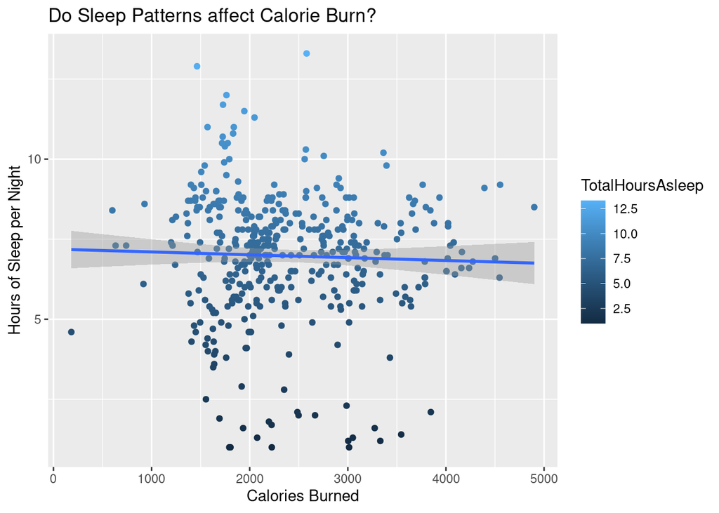

```r
ggplot(dailysleep, aes(x=Calories, y=TotalHoursAsleep, color = TotalHoursAsleep))+
  geom_point()+
  geom_smooth(method = "lm")+
  labs(title = "Do Sleep Patterns affect Calorie Burn?", x='Calories Burned', y='Hours of Sleep per Night')
```

### Plot showing sedentary minutes per day and hours of sleep per night

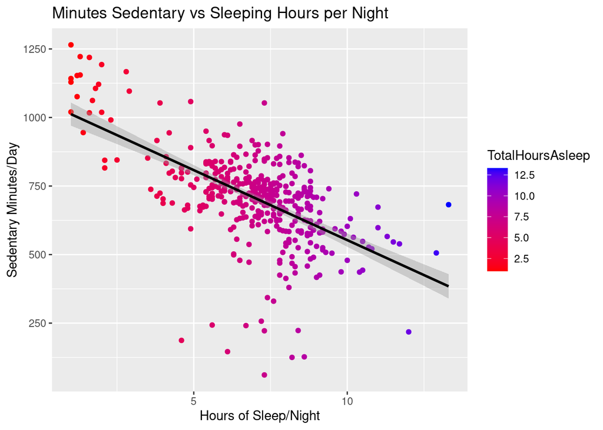

```r
ggplot (dailysleep, aes(x = TotalHoursAsleep, y = SedentaryMinutes, color = TotalHoursAsleep))+
  geom_point()+
  scale_color_gradient(low = 'red', high = 'blue')+
  labs(title = 'Minutes Sedentary vs Sleeping Hours per Night', x='Hours of Sleep/Night', y='Sedentary Minutes/Day')+
  geom_smooth(method = 'lm', color = 'black')
```

We have a clear correlation between Sedentary Minutes per Day and Hours of Sleep/Night. The more time spent being sedentary during the day, the chart shows it is likely to lead to less hours of sleep per night. This can be a great opportunity to motivate consumers to be more active if they want to achieve a healthy sleep cycle

### **Overall recommendations for Bellabeat**

Through all this data you can see some clear patterns, however I believe the dataset is too small to make any real marketing recommendations. I also think not having the age of the participants is a big factor and can really skew this data.  
**Sample size:**  
-35 participants in the daily activity data set  
-24 participants in the sleep statistics data set  
-33 participants in the steps data set